# Unbalanced trials and environment-specific variances

Muhammad Yaseen

2026-11-09

# 1 Abstract

Real trials lose plots, and some genotypes are not grown in every environment. The error variance also differs from one site to the next. This vignette shows how `bayes_ammi()` handles both: missing plots and empty cells by data augmentation, and a separate error variance for every environment with `.het = TRUE`. It ends with a comparison of the two variance models on `Maiz`.

# 2 Missing plots and empty cells

## 2.1 The idea

With $B$ the largest number of plots in a cell, a cell $(i, j)$ with $n_{ij} < B$ plots has $B - n_{ij}$ missing plots. A cell with $n_{ij} = 0$ is an empty cell. At every iteration the sampler draws the missing plots from the model,
$$y^{\mathrm{mis}}_{ijl} \mid \vtheta \sim N(\eta_{ij}, \sigma^2_j), \qquad \eta_{ij} = \mu + \tau_i +
\delta_j + \sum_{k=1}^{K}\lambda_k\alpha_{ik}\gamma_{jk},$$
and then draws the parameters from the conditional distributions of the balanced design (vignette 2) given the completed data. This is the data augmentation of Tanner and Wong (1987). The draws of the parameters come from their posterior given the observed plots only, so nothing is invented: a missing plot adds no information, and an empty cell is predicted from the row and column structure of the model. The missing plots are assumed to be missing at random (Little and Rubin 2019).

The sampler needs only the sums, sums of squares and counts of the observed plots in every cell, so the completed data are never stored.

## 2.2 An example

From `Maiz` we remove 60 plots at random and every plot of three genotype-environment combinations:

```r
set.seed(seed = 21)
mz   <- Maiz[-sample(x = nrow(Maiz), size = 60), ]
gone <- (mz$entry == 2 & mz$site == 5) | (mz$entry == 7 & mz$site == 11) | (mz$entry == 9 & mz$site == 18)
mz   <- mz[!gone, ]
table(plots = table(factor(mz$entry):factor(mz$site)))
```

```
plots
  0   1   2   3   4
  3   1   5  47 124
```

```r
fu <-
  bayes_ammi(
      .data   = mz
    , .y      = y
    , .gen    = entry
    , .env    = site
    , .rep    = rep
    , .nIter  = 3000
    , .k      = 2
    , .burnin = 500
    , .thin   = 1
    , .chains = 2
    , .priors = bam_priors(
          mu_mean     = 0
        , mu_var      = 1e+8
        , tau_mean    = 0
        , tau_var     = 1e+8
        , delta_mean  = 0
        , delta_var   = 1e+8
        , lambda_mean = 0
        , lambda_var  = 1e+8
        , nu          = 1
        , s2          = NULL
        )
    , .level  = 0.95
    , .seed   = 3
    , .align  = TRUE
    , .model  = "AMMI"
    , .het    = FALSE
    , .waic   = TRUE
    )
fu
```

```
Bayesian AMMI with 2 multiplicative term(s): 9 genotypes, 20 environments, 648 plots (3 empty cells)
2 chain(s) x 3000 kept draws (iterations 3000 after a burn-in of 500, thinning 1); 1.7 s

Posterior means, standard deviations and 95% HPD intervals
    parameter       mean       sd      lower     upper   ess   rhat
       <char>      <num>    <num>      <num>     <num> <num>  <num>
 1:        mu   4865.378    34.85  4.797e+03   4931.90  4639 1.0023
 2:    sigma2 771133.151 45862.81  6.884e+05 866667.90  3493 1.0004
 3:    tau[1]   -235.197    95.45 -4.318e+02    -56.12  5393 1.0003
 4:    tau[2]   -287.087    99.35 -4.902e+02   -100.13  4427 1.0000
 5:    tau[3]    -16.772    97.76 -2.130e+02    165.23  5358 1.0002
 6:    tau[4]    368.080    96.72  1.815e+02    557.44  5813 1.0006
 7:    tau[5]    395.278    95.27  2.256e+02    600.17  5604 1.0004
 8:    tau[6]    439.592    99.69  2.415e+02    628.05  4629 1.0000
 9:    tau[7]   -197.581   105.05 -4.019e+02     10.22  3681 1.0001
```

[output cut: 31 more lines]

The print shows the number of empty cells. `bam_predict()` gives the posterior of every cell mean $\eta_{ij}$, including the empty cells:

```r
pu <-
  bam_predict(
      fit    = fu
    , .level = 0.95
    )
pu$cells[n == 0]
```

```
      Gen    Env     n observed     mean       sd    lower    upper
   <fctr> <fctr> <int>    <num>    <num>    <num>    <num>    <num>
1:      2      5     0       NA 4369.859 279.9944 3794.720 4891.308
2:      7     11     0       NA 4903.347 322.4456 4269.447 5523.364
3:      9     18     0       NA 4761.894 311.5227 4165.312 5390.920
```

```r
Maiz_cells <- data.table::as.data.table(x = Maiz)[, list(full = mean(y)), by = list(
    Gen = factor(entry)
  , Env = factor(site)
  )]
merge(x = pu$cells[n == 0], y = Maiz_cells, by = c("Gen", "Env"))[, list(
    Gen
  , Env
  , mean
  , lower
  , upper
  , full
  )]
```

```
Key: <Gen, Env>
      Gen    Env     mean    lower    upper     full
   <fctr> <fctr>    <num>    <num>    <num>    <num>
1:      2      5 4369.859 3794.720 4891.308 5201.475
2:      7     11 4903.347 4269.447 5523.364 5051.575
3:      9     18 4761.894 4165.312 5390.920 5244.400
```

The column `full` holds the cell means of the complete data, which the fit never saw. 2 of the 3 HPD intervals contain them. The miss, genotype 2 in environment 5, is a cell whose interaction is not carried by the two bilinear terms: the model predicts an empty cell only from the pattern of the rest of the trial. The posterior standard deviations of the empty cells are on average 1.1 times those of the cells with all four plots.

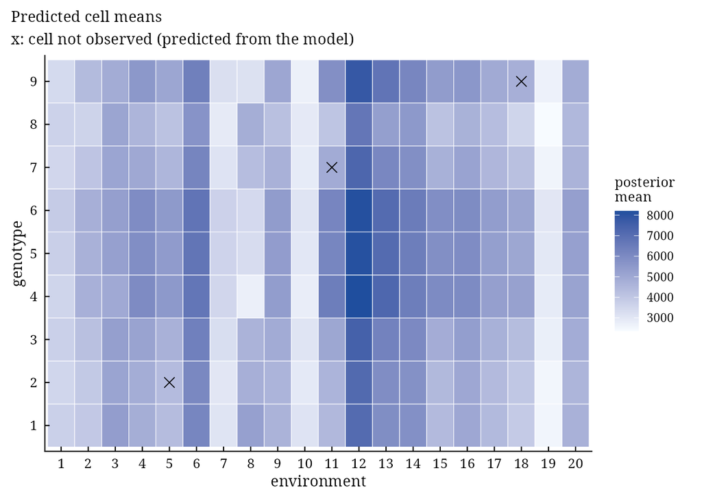

```r
plot(x = pu, which = "cells")
```

# 3 Environment-specific error variances

## 3.1 The model

With `.het = TRUE` the plots of environment $j$ have their own variance, $e_{ijl} \sim N(0, \sigma^2_j)$, and every $\sigma^2_j$ has the scaled inverse chi-squared prior of the common variance. Write $w_j = 1/\sigma^2_j$. The conditional distributions change as follows.

- $\sigma^2_j$: scaled inverse chi-squared with $\nu + BG$ degrees of freedom and the residual sum of squares of environment $j$.
- $\tau_i$: the data precision becomes $B\sum_j w_j$, the same for every genotype.
- $\mu$ and $\delta_j$: no longer independent, so $(\mu, \mathbf{d})$ is drawn jointly from its multivariate normal conditional.
- $\lambda_k$: mean and variance weighted by $w_j$.
- $\va_k$: still von Mises-Fisher, because the quadratic term $\sum_j w_j\gamma_{jk}^2$ does not depend on $\va_k$.
- $\vg_k$: the quadratic term $\sum_j w_j\gamma_{jk}^2$ now varies on the sphere. The conditional is a Bingham-von Mises-Fisher distribution (Hoff 2009), drawn one coordinate at a time in the eigenbasis of the quadratic form by slice sampling.

Perez-Elizalde et al. (2012) give the general linear-bilinear model with these conditionals.

## 3.2 The fit

```r
fh <-
  bayes_ammi(
      .data   = Maiz
    , .y      = y
    , .gen    = entry
    , .env    = site
    , .rep    = rep
    , .nIter  = 3000
    , .k      = 2
    , .burnin = 500
    , .thin   = 1
    , .chains = 2
    , .priors = bam_priors(
          mu_mean     = 0
        , mu_var      = 1e+8
        , tau_mean    = 0
        , tau_var     = 1e+8
        , delta_mean  = 0
        , delta_var   = 1e+8
        , lambda_mean = 0
        , lambda_var  = 1e+8
        , nu          = 1
        , s2          = NULL
        )
    , .level  = 0.95
    , .seed   = 4
    , .align  = TRUE
    , .model  = "AMMI"
    , .het    = TRUE
    , .waic   = TRUE
    )
fh$summary[block == "sigma2", list(parameter, mean, lower, upper, rhat)]
```

```
     parameter       mean      lower     upper      rhat
        <char>      <num>      <num>     <num>     <num>
 1:  sigma2[1]  899051.19  511891.64 1349890.6 1.0006236
 2:  sigma2[2]  359098.16  192026.52  555745.0 0.9998866
 3:  sigma2[3] 1358450.15  751176.80 2064839.8 1.0065478
 4:  sigma2[4]  265204.01  143568.41  406218.9 0.9998684
 5:  sigma2[5]  486396.32  270327.39  743027.4 1.0003240
 6:  sigma2[6]  542883.85  302578.54  865847.9 1.0000071
 7:  sigma2[7]  485314.39  269353.19  740659.9 1.0036182
 8:  sigma2[8] 1083672.16  514349.66 1779086.2 1.0011059
 9:  sigma2[9] 1735925.45 1033048.68 2624506.7 0.9998791
10: sigma2[10]   90216.12   47092.66  139392.2 0.9998561
11: sigma2[11]  987914.43  558046.74 1522479.9 1.0007315
12: sigma2[12]  639387.39  368112.12  997579.5 1.0002132
13: sigma2[13]  912822.78  513857.36 1405516.9 0.9999362
14: sigma2[14] 1048576.95  599100.73 1565103.0 1.0005215
15: sigma2[15]  582948.13  304895.26  882299.0 1.0003107
16: sigma2[16]  301506.87  170387.93  455563.0 1.0000115
17: sigma2[17]  589627.10  309397.79  904723.1 1.0035253
18: sigma2[18] 1369988.68  742355.05 2056858.1 1.0005439
19: sigma2[19] 2031831.15 1162647.09 3044867.7 0.9998868
20: sigma2[20]  392824.32  208244.34  594441.1 1.0014998
     parameter       mean      lower     upper      rhat
        <char>      <num>      <num>     <num>     <num>
```

The posterior means range from 90,216 to 2,031,831, a ratio of 23. One common variance cannot describe both extremes.

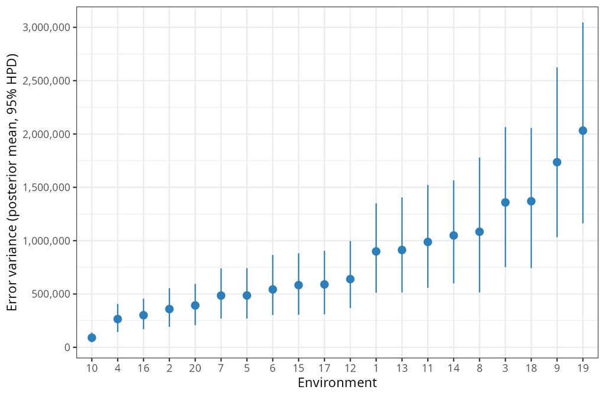

```r
ggplot2::ggplot(
    data    = fh$summary[block == "sigma2"]
  , mapping = ggplot2::aes(x = reorder(label, mean), y = mean, ymin = lower, ymax = upper)
  ) +
  ggplot2::geom_pointrange(colour = "#2c7fb8") +
  ggplot2::scale_y_continuous(breaks = scales::pretty_breaks(n = 6), labels = scales::label_comma()) +
  ggplot2::labs(x = "Environment", y = "Error variance (posterior mean, 95% HPD)") +
  ggplot2::theme_bw()
```

# 4 Which variance model?

```r
fc <-
  bayes_ammi(
      .data   = Maiz
    , .y      = y
    , .gen    = entry
    , .env    = site
    , .rep    = rep
    , .nIter  = 3000
    , .k      = 2
    , .burnin = 500
    , .thin   = 1
    , .chains = 2
    , .priors = bam_priors(
          mu_mean     = 0
        , mu_var      = 1e+8
        , tau_mean    = 0
        , tau_var     = 1e+8
        , delta_mean  = 0
        , delta_var   = 1e+8
        , lambda_mean = 0
        , lambda_var  = 1e+8
        , nu          = 1
        , s2          = NULL
        )
    , .level  = 0.95
    , .seed   = 4
    , .align  = TRUE
    , .model  = "AMMI"
    , .het    = FALSE
    , .waic   = TRUE
    )
cp <-
  bam_compare(
      common          = fc
    , environment_var = fh
    )
cp
```

```
Comparison of Bayesian models (smaller is better)

             model terms       variances      DIC      pD     WAIC  p_waic
            <char> <int>          <char>    <num>   <num>    <num>   <num>
1: environment_var     2 per environment 11735.63 85.6869 11741.45 82.0777
2:          common     2          common 11862.02 67.9290 11865.68 65.9309
        se lambda_last_lower lambda_last_mean    dWAIC dWAIC_se
     <num>             <num>            <num>    <num>    <num>
1: 41.9641          910.1783         2093.077   0.0000   0.0000
2: 44.2329           63.7490         1686.287 124.2365  22.4796

Sources: Spiegelhalter et al. (2002); Watanabe (2010); Vehtari et al. (2017).
Full references: bam_cite(x).
```

The environment-specific variances lower WAIC by 124, 5.5 times the standard error of the difference. They also sharpen the interaction: the lower HPD limit of $\lambda_2$ rises from 64 to 910, because the plots of the noisy environments no longer blur the second term. The posterior predictive check of the common-variance model tells the same story through the ratio of the largest to the smallest environment variance:

```r
pp <-
  bam_ppc(
      fit    = fc
    , .draws = 500
    , .seed  = 1
    )
pp
```

```
Posterior predictive checks (500 replicated trials)

                                 statistic  observed  mean_rep p_value
                                    <char>     <num>     <num>   <num>
1:                  variance of cell means 1.842e+06 1.901e+06   0.682
2:                       largest cell mean 8.385e+03 8.608e+03   0.728
3:                      smallest cell mean 1.632e+03 1.743e+03   0.672
4:              variance of genotype means 1.247e+05 1.429e+05   0.662
5:                    first singular value 5.923e+03 5.902e+03   0.482
6:                    within-cell variance 7.559e+05 7.660e+05   0.526
7: largest / smallest environment variance 2.582e+01 2.924e+00   0.000

Sources: Gelman et al. (1996). Full references: bam_cite(x).
```

The observed ratio is 26, against 2.9 on average in the replicated trials of the common-variance model (posterior predictive p-value 0.000). The other statistics are reproduced well. Vignette 9 returns to these tools.

# 5 References

Crossa, J., Perez-Elizalde, S., Jarquin, D., Cotes, J. M., Viele, K., Liu, G. and Cornelius, P. L. (2011). Bayesian estimation of the additive main effects and multiplicative interaction model. *Crop Science*, 51(4), 1458–1469. doi:10.2135/cropsci2010.06.0343

Perez-Elizalde, S., Jarquin, D. and Crossa, J. (2012). A general Bayesian estimation method of linear-bilinear models applied to plant breeding trials with genotype x environment interaction. *Journal of Agricultural, Biological, and Environmental Statistics*, 17, 15–37. doi:10.1007/s13253-011-0063-9

Hoff, P. D. (2009). Simulation of the matrix Bingham-von Mises-Fisher distribution, with applications to multivariate and relational data. *Journal of Computational and Graphical Statistics*, 18(2), 438–456.

Tanner, M. A. and Wong, W. H. (1987). The calculation of posterior distributions by data augmentation. *Journal of the American Statistical Association*, 82(398), 528–540.

Little, R. J. A. and Rubin, D. B. (2019). *Statistical Analysis with Missing Data*, 3rd edn. Wiley, Hoboken.